# 4. {ggplot2} (basic)

Masahiko Asano

2026-07-26

- R pacaghes needed in this section

```r
library(gghighlight)
library(ggplot2) # {tidyverse} includes {ggplot2}
library(ggrepel)
library(magrittr)# {tidyverse} includes {magrittr}
library(patchwork)
library(plotly)
library(reactable)
```

# 1. Drawing a graph on R

- The most basic syntax of `R` is called “`base R`.”
- The {`ggplot2`} is a package included in a packaged called the {`tidyverse`}.
- Two ways of drawing a graph on `R`

| 1. **Base R** | The most basic syntax of `R` |
| --- | --- |
| 2. **ggplot2** | Draw a graph by adding layers |

- Examples of drawing a graph on `base R` and `{ggplot2}`

[figure not shown]

- You can draw a graph either on `base R` or on `{ggplot2}`
- But, drawring a graph on`{ggplot2}` is way convenient

# 2. What is `{ggplot2}`?

- An R package made by Hadley Wickham for data visualization
- **gg**plot: the **g**rammer of **g**raphics
- Hadley Wickham distributes [{ggplot2}](https://ggplot2-book.org) for free

## 2.1 Two core features on `{ggplot2}`

[output not shown]

## 2.2 Advantages of using `{ggplot2}`

1. `R code` is easier to read and neat
2. Easy to change a graphical outlook
3. Reproducibility of a graph is guranteed
4. You can write `R code` based on graphical grammar
5. Graphical components works as `layers`
6. Superior as a tool for an academic explorataion
7. Abundant R pachages
8. Abndant `{ggplot2}` communities

## 2.3 Preparing `{ggplot2}`

- You need to install and read `{tidyverse}` to start using `{ggplot2}` on Rmd file
- The `{tidyverse}` is a family of packages, including `{ggplott2}`, `{dplyr}`, `{tidyr}`, `{readr}`, `{purrr}`, `{tibble}` and a few others which are useful for data manipuration and data visualization
- The `{tidyverse}` is in continuing development, meaning that some of the fuctions are subject to change though many of the core functions are fairly unchaged.
- If you encounter difficulties getting your R code to run, it may be because of the `{tidyverse}` has changed.
- If this is the case, then you can look up documentation about the package to learn how to update your code.

[figure not shown]

- Since `{tidyverse}` contains `{ggplot2}`, all you have to do is to load `{tidyverse}`
- To use `{tidyverse}`, you need to take the following 2 steps:

##### 1. install `{tidyverse}`

- You type install.packages(“tidyverse”) in `Console`  
  → Hit the `Return key`

```r
install.packages("tidyverse")
```

- You need to do this only once
- `install.packages("tidyverse")` will download the required package materials to your computer.

##### 2. Load `{tidyverse}`

- After you have successfully download `{tidyverse}`, you load it for your current `Rmd file` with the `library(tidyverse)`
- You type `library(tidyverse)` in a chunk  
  → Click `knit`

```r
library(tidyverse)
```

- Although you do not need to install `{tidyverse}` at the start of every R session (or R script), you do need to load `{tidyverse}` every time.
- If you receive an error that a certain function is not found, it may mean that you forget to run a `library(tidyverse)` command for `{tidyverse}` that contains that function, such as `ggplot()` or `readr()`, etc.

# 3. How does {ggplot2} work?

- I will introduce how {`ggplot2`} works here
- As an example, I will draw a scatterplot using {`ggplot2`} and how to customize it
- You need the following three minimum components to draw a scatterplot using {`ggplot2`}

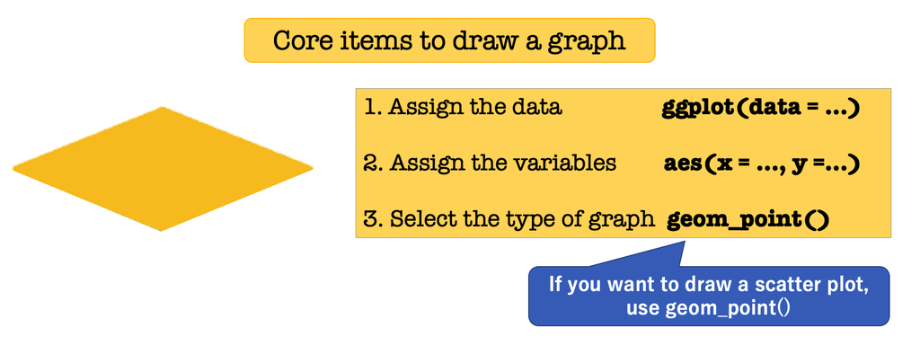

3 minimum components to draw a scatterplot using {`ggplot2`}

| **Item** | **`{package}:function()`** | **What the item does** |
| --- | --- | --- |
| **1. Assign the data** | `ggplot(data = )` | Select the data |
| **2. Assign the variables** | `aes()` | Select the variables, such as `x`, `y` |
| **3. Assgin a graph** | `geom_*()` | Select the type of graph |

##### 1. Select the data

- In drawing a graph using `{ggplt2}`, you need to use a `tidy data` which is easy to read for a computer, but not for us
- For details on `tidy data`, see [1. Data Handling(Advance)](http://www.ner.takushoku-u.ac.jp/masano/class_material/waseda/keiryo/RE01_data_handling_advance.html)

##### 2. Assign the variables

- Selecting variables for `x` axis and `y` axis is called “mapping”
- “Mapping” means corresponding dots, lines and surface to data and variables
- “Mapping” means assigning how data is visualized
- In mapping, `aes()` function is used
- `aes()` means `aesthetics`
- You can assign multiple arguments within the parenthesis, `()`

##### 3. Assign a graph

- You can choose a most appropriate graph for your data by selecting geometric objects, shown as `geom_*()`
- The following four geometric objects are the most frequently used

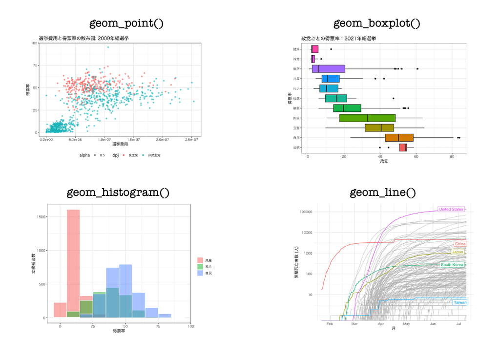

#### `geom_*()`

[output not shown]

- In this section, we use `geom_point()` to draw scatter plot

#### Image of how {`ggplot2`} complete a graph

- `{ggplot2}` takes a graphical element as a layer
- Geometric objects, such as `ggplot()`, `geom_point()`, `scale()` generate the layers
- Each individual geometric object is added with an operator, `+`
- First, you assign three essential items:`ggplot()`, `aes()`, `geom_point()`
- Depending on what kind of graph you want to draw, you can customize colors, shape, and size of your graph using `scale` function - You can customize `x axis` and `y axis` using `coord` function
- Let me show you the image of how {`ggplot2`} complete a graph

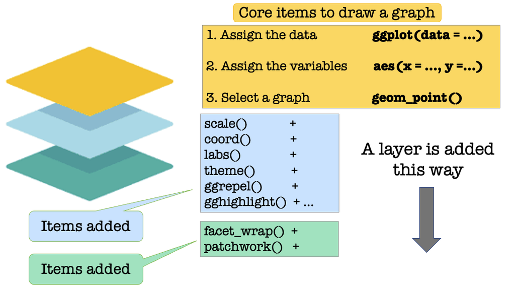

The image of how {`ggplot2`} complete a graph

・**Core items to draw a graph**  
・**Layers customizing outlook of a graph**  
・**Layers customizing outlook of a graph**

- **You don’t have to memorize entire R code**
- It would be good for you to understand the mechanism how {`ggplot2`} works, and write your R code googling on the web
- For details on how to write a graph using {`ggplot2`}, see 「`5. ggplot2 (Barchart)` 〜 `ggplot2 (Dot plot)`」

#### Let’s draw a scatter plot using a fake data (`df1`)

- Suppose you want to use data frame (`df1`)
- Set math score (`math`) as `x axis`
- Set statistics score (`stat`) as `y axis`
- Change colors of the dot by `gender`

##### Two ways of assigning `aes()` for entire graph:

|  | Range of assignment |
| --- | --- |
| (1) Assign `aes()` as an independent layer | Whole graph |
| (2) Assign mapping argument within `ggplot()` | Whole graph |

##### (1) Assign mapping argument, `aes()`, as an independent layer

```r
library(ggplot2)
```

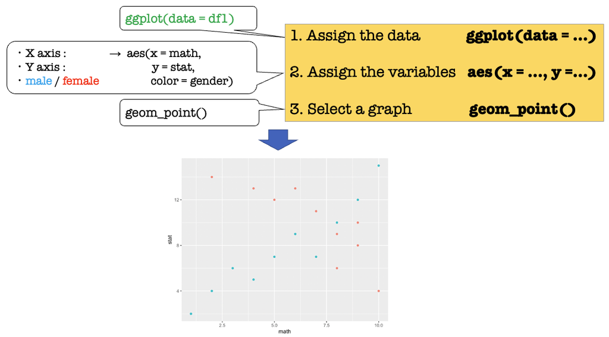

```r
ggplot(data = df1) +
  aes(x = math,
  y = stat,
  color = gender) +
  geom_point()
```

##### (2) Assign mapping argument, `aes()`, within `ggplot()`

```r
library(ggplot2)
```

```r
ggplot(data = df1,
   mapping = aes(x = math,
y = stat,
color = gender)) +
  geom_point()
```

[output not shown]

- You get the same results from `(2)` and `(1)`

How to assign `aes()`） ・If you type the following R code, you can get a simple scatter plot  
・You can get the same scatter plot in three ways:

#### (1) Assign mapping argument, `aes()`, as an independent layer

```r
ggplot(df1) +
  aes(x = math,  # aes() is an independent layer
  y = stat,
  color = gender) +
  geom_point()
```

#### (2) Assign mapping argument, `aes()`, within `ggplot()`

```r
ggplot(df1,
   mapping = aes(x = math, # mapping = omissible
y = stat,
color = gender)) +
  geom_point()
```

#### 3. Assign mapping argument, `aes()`, within `geom_point()`

```r
ggplot(df1) +
  geom_point(mapping = aes(x = math, # mapping = は省略できる
  y = stat,
  color = gender))
```

- You can draw a simple scatter plot in these three ways
- But, you need to make it a better one by customizing it
- You can make customize it by adding another layer

#### 10 most commonly used layers:

| **Elements** | **`{package}:function()`** | **What you can do** |
| --- | --- | --- |
| **1. Labels** | `labs*()` | Customize the labels on legend and axis |
| **2. Theme** | `theme_()`, `theme_*()` | Customize the outlook of a graph |
| **3. Coordinate System** | `coord_*()` | Customize the outlook of coordinate system |
| **4. Statistics** | `stat_*()` | Customize statistical stuff |
| **5. Scale** | `scale_*()_` | Customize glaph’s colors and shapes |
| **6. Hilight** | `{gghighlight}` | Emphasizing a particular data |
| **7. Identifying dots** | `{ggrepel}` | Identify what dots represent in scatter plot |
| **8. Facet** | `facet_*()` | Making multiple graphs |
| **9. Patchwork** | `{patchwork}` | Arranging multiple graphs |
| **10. Interactive graph** | `{plotly}` | Making an interactive graph |